# PISA Data Analysis

PISA is a survey of students' skills and knowledge as they approach the end of compulsory education. It is not a conventional school test. Rather than examining how well students have learned the school curriculum, it looks at how well prepared they are for life beyond school.

Around 510,000 students in 65 economies took part in the PISA 2012 assessment of reading, mathematics and science representing about 28 million 15-year-olds globally. Of those economies, 44 took part in an assessment of creative problem solving and 18 in an assessment of financial literacy.

# Univariate Exploration and Analysis

How are scores for each subject distributed?

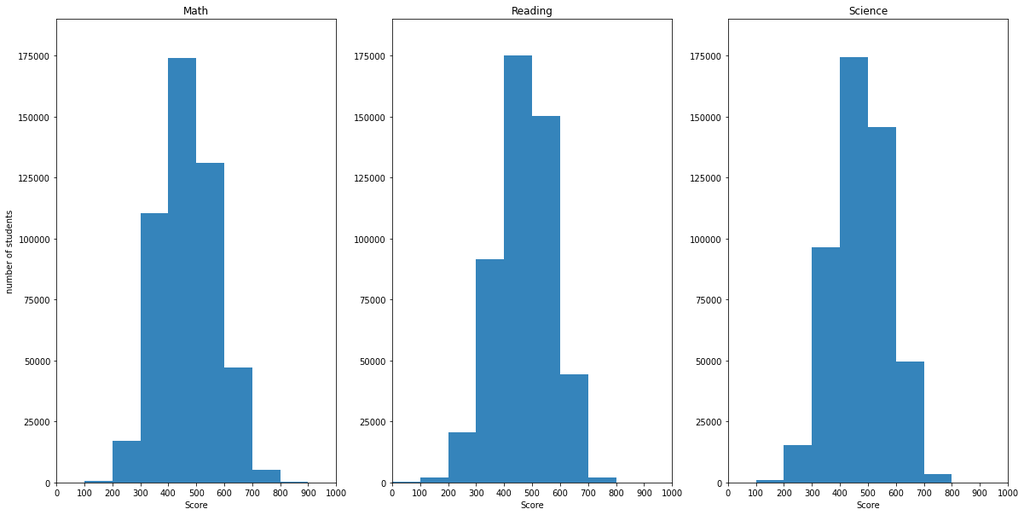

```python
plt.figure(figsize = [20, 10])

bins_hist = np.arange(0, 1000 + 1, 100)

plt.subplot(1, 3, 1)
plt.hist(df['Math_score'], bins = bins_hist, alpha = 0.9);
plt.xlim(0, 1000);
plt.ylim(0, 190000 + 1);
plt.xticks(bins_hist)
plt.xlabel('Score');
plt.ylabel('number of students')
plt.title('Math');

plt.subplot(1, 3, 2)
plt.hist(df['Reading_score'], bins = bins_hist, alpha = 0.9);
plt.xlim(0, 1000);
plt.ylim(0, 190000 + 1);
plt.xticks(bins_hist)
plt.xlabel('Score');
plt.title('Reading');

plt.subplot(1, 3, 3)
plt.hist(df['Science_score'], bins = bins_hist, alpha = 0.9);
plt.xlim(0, 1000);
plt.ylim(0, 190000 + 1);
plt.xticks(bins_hist)
plt.xlabel('Score');
plt.title('Science');
```

The scores show a normal distribution, with most students having an average score (between 400 to 500) in either Math, Reading or Science. For math, we can see that when compred with reading or science more students are achieving on the lower end of the spectrum, which indicates that math might be considered more "difficult" to students than the other two subjects.

Which countries have the most "brilliant" students (with scores higher than 700) (above average) per subject?

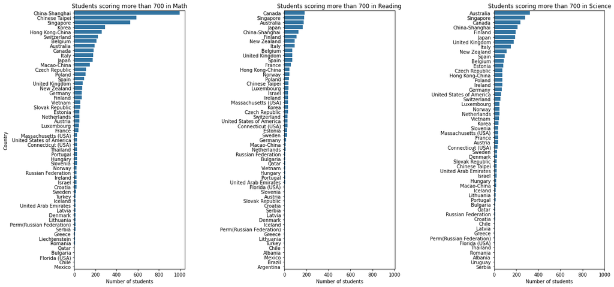

```python
# Get number of students with scores above 800 points per subject

math_700 = df[df['Math_score'] > 700]['Country'].value_counts()
reading_700 = df[df['Reading_score'] > 700]['Country'].value_counts()
science_700 = df[df['Science_score'] > 700]['Country'].value_counts()

plt.figure(figsize = [20, 10])
plt.subplots_adjust(wspace = 0.9)
x_lim_max = math_700.values[0] + 6


plt.subplot(1, 3, 1)
sb.barplot(y = math_700.index, x = math_700.values, color = sb.color_palette()[0])
plt.title('Students scoring more than 700 in Math');
plt.xlabel('Number of students')
plt.ylabel('Country')

plt.subplot(1, 3, 2)
sb.barplot(y = reading_700.index, x = reading_700.values, color = sb.color_palette()[0])
plt.xlim(0, x_lim_max);
plt.title('Students scoring more than 700 in Reading');
plt.xlabel('Number of students')


plt.subplot(1, 3, 3)
sb.barplot(y = science_700.index, x = science_700.values, color = sb.color_palette()[0])
plt.xlim(0, x_lim_max);
plt.title('Students scoring more than 700 in Science');
plt.xlabel('Number of students')
```

What is the proportion of students having parents with same or different country?

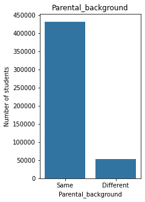

```python
plt.figure(figsize=[3, 5]);
sb.countplot(x = 'Parental_background', data = df, color = sb.color_palette()[0]);

y_ticks = np.arange(0, 450000 + 1, 50000)
plt.yticks(y_ticks, y_ticks);
plt.ylabel('Number of students');
plt.title('Parental_background');
```

The majority of students have parents from the same country, which makes sense as it is more likely that parents will be from same country.

# Bivariate Exploration and Analysis

How does student country affect scores per subject?

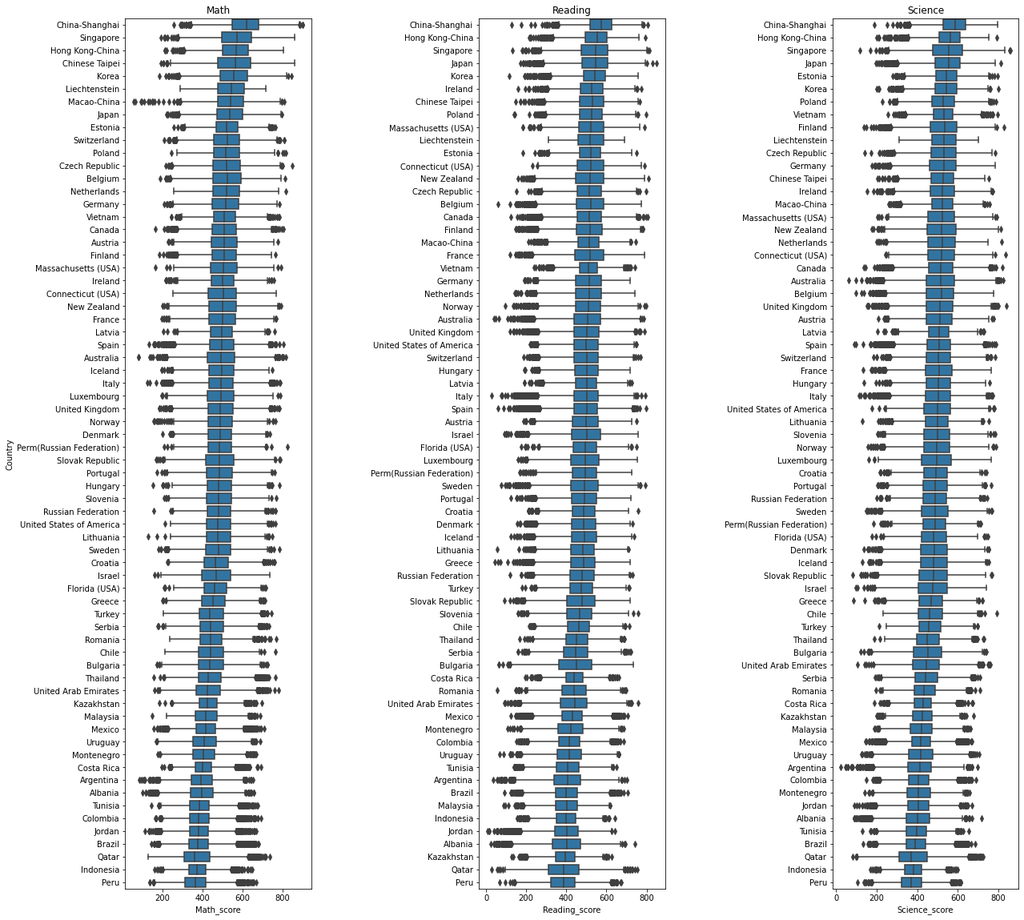

```python
plt.figure(figsize = [20, 20])
plt.subplots_adjust(wspace = 0.9)

math_country_order = df.groupby('Country')['Math_score'].mean().sort_values(ascending = False).index
reading_country_order = df.groupby('Country')['Reading_score'].mean().sort_values(ascending = False).index
science_country_order = df.groupby('Country')['Science_score'].mean().sort_values(ascending = False).index

plt.subplot(1, 3, 1)
sb.boxplot(x = df['Math_score'], y = df['Country'], order = math_country_order, color = sb.color_palette()[0]);
plt.ylabel('Country')
plt.title('Math');

plt.subplot(1, 3, 2)
sb.boxplot(x = df['Reading_score'], y = df['Country'], order = reading_country_order, color = sb.color_palette()[0]);
plt.ylabel('');
plt.title('Reading');

plt.subplot(1, 3, 3)
sb.boxplot(x = df['Science_score'], y = df['Country'], order = science_country_order, color = sb.color_palette()[0]);
plt.ylabel('');
plt.title('Science');
```

- Asian countries such as China, Singapore, and Japan have, on average, the highest scoring students in all three subjects, indicating a strong education system in those countries.
- Peru is the country with the lowest average score in all three subjects, which hints at a need of improvement in their education system.
- Mid-east countries such as Qatar, Tunisia, and Jordan have the low scoring students in all three subjects, which also hints that the education system needs some optimization in this area.

Which countries have the most "brilliant" students (with scores higher than 700) (above average) in multiple subjects simeltanously?

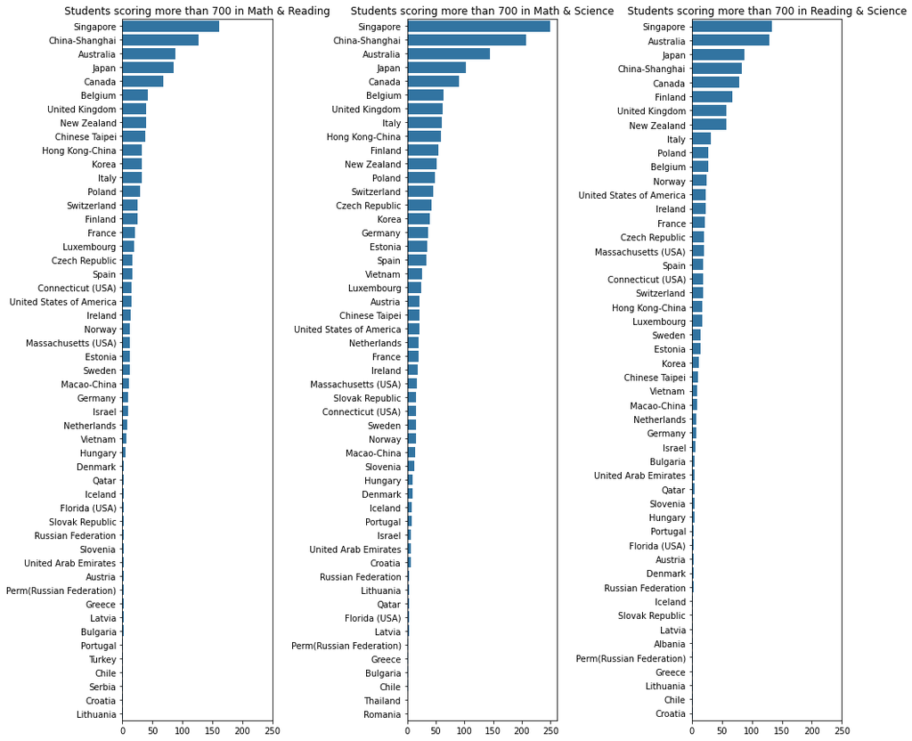

```python
high_math_reading_score = df[(df['Math_score'] >= 700) & (df['Reading_score'] >= 700)]['Country'].value_counts()
high_math_science_score = df[(df['Math_score'] >= 700) & (df['Science_score'] >= 700)]['Country'].value_counts()
high_reading_science_score = df[(df['Reading_score'] >= 700) & (df['Science_score'] >= 700)]['Country'].value_counts()

plt.figure(figsize = [15, 15])
plt.subplots_adjust(wspace = 0.9)
x_lim_max = high_math_science_score.values[0]

plt.subplot(1, 3, 1)
sb.barplot(y = high_math_reading_score.index, x = high_math_reading_score.values, color = sb.color_palette()[0])
plt.title('Students scoring more than 700 in Math & Reading');
plt.xticks(np.arange(0, x_lim_max + 2, 50));

plt.subplot(1, 3, 2)
sb.barplot(y = high_math_science_score.index, x = high_math_science_score.values, color = sb.color_palette()[0])
plt.title('Students scoring more than 700 in Math & Science');
plt.xticks(np.arange(0, x_lim_max + 2, 50));

plt.subplot(1, 3, 3)
sb.barplot(y = high_reading_science_score.index, x = high_reading_science_score.values, color = sb.color_palette()[0])
plt.title('Students scoring more than 700 in Reading & Science');
plt.xticks(np.arange(0, x_lim_max + 2, 50));
```

Singapore has the overall highest number of above average scoring students in multiple subjects simeltanously, China, Australia, Canada, and Japan also have multi-talented students.

How does having parents from same and different cultural backgrounds affect student scores?

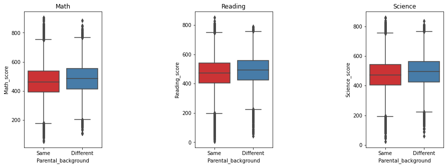

```python
plt.figure(figsize = [15, 5])
plt.subplots_adjust(wspace = 1.2)

plt.subplot(1, 3, 1)
sb.boxplot(x = df['Parental_background'], y = df['Math_score'], palette = 'Set1')
plt.title('Math');

plt.subplot(1, 3, 2)
sb.boxplot(x = df['Parental_background'], y = df['Reading_score'], palette = 'Set1')
plt.title('Reading');

plt.subplot(1, 3, 3)
sb.boxplot(x = df['Parental_background'], y = df['Science_score'], palette = 'Set1');
plt.title('Science');
```

Students with parents having different cultural background have higher scores in all three subjects on average, which may be due to increased versatility in upbringing which stimulates the brain and leads to higher achievement.

# Multivariate Exploration and Analysis

How are the scores between each subject correlated?

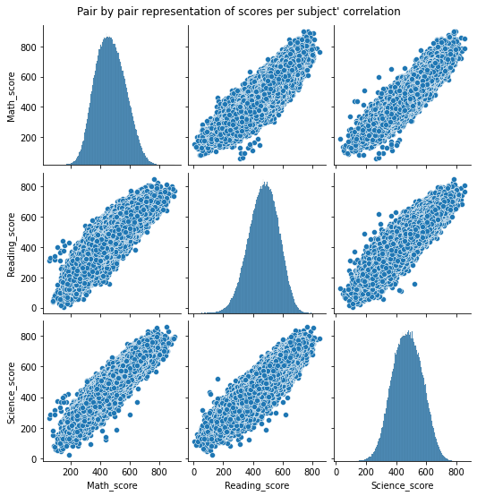

```python
grid = sb.pairplot(data = df, vars=["Math_score", "Reading_score", "Science_score"]);
grid.fig.suptitle("Pair by pair representation of scores per subject' correlation", y = 1.02);
```

- A strong and positive correlation between the score of any two subjects is seen, indicating that students scoring high one subject tend to score high in the other two subjects.
- It can be noticed that for a small number of students math performance may be disproportionaely weaker than reading or science performance.

What countries have more than a 10 position difference between rankings in each subject are obtained, and what subject(s) is the cause of this anomaly?

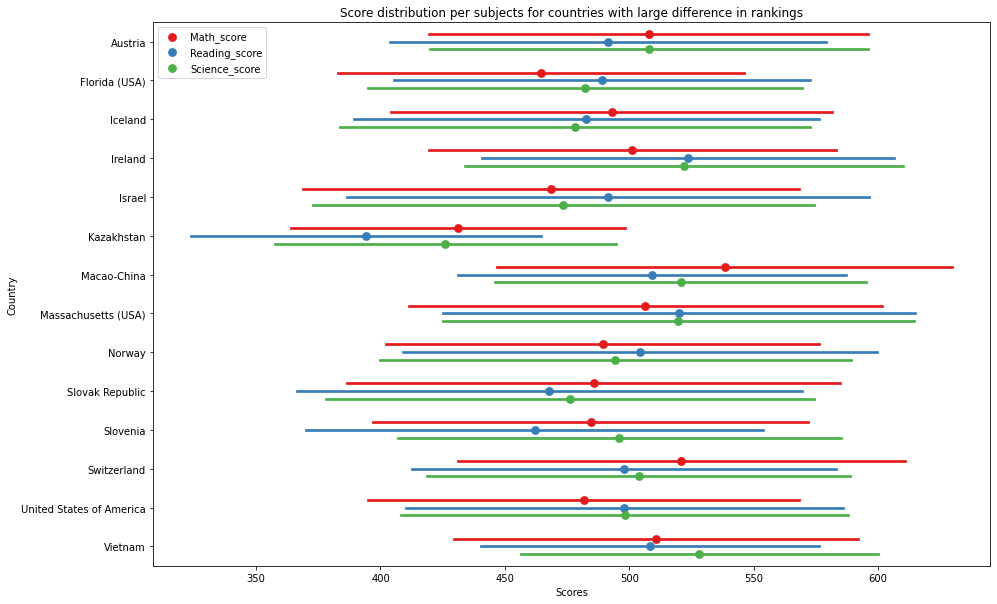

```python
df_country_anomaly = df[['Country', 'Math_score', 'Reading_score', 'Science_score']][df['Country'].isin(country_anomaly)]
df_country_anomaly = df_country_anomaly.melt('Country', var_name = 'Score Type', value_name = 'Scores')

plt.figure(figsize = [15, 10])

sb.pointplot(x = 'Scores', y = 'Country', hue = 'Score Type', data = df_country_anomaly, linestyles = '', dodge = 0.4, ci = 'sd', palette = 'Set1', order = country_anomaly);
plt.legend(loc = 2);
plt.title('Score distribution per subjects for countries with large difference in rankings');
```

for each country, we can see the subject(s) which is outlying from other scores. For example, in the USA math scores are disproportionately lower than reading/science scores, which inducates that more focus should be given to that subject and that changes should be made to the math syllabus or method of teaching in that country.

# Conclusion and Summary of Results